# “Survivor” (TV Show) Analysis: Who Earns the Jury Vote?

Brianna Beitling

## I. Introduction

### A. Study Design.

In 2000, “Survivor Fever” swept the nation as millions watched one of the first reality television shows unfold on their television screens. The commercials and advertisements preceding its inaugural episode led some to believe there might actually be some degree of brutality and danger to the situation- that perhaps even the contestants’ lives were at stake- a la “Battle Royale” or “The Hunger Games”. While that was, of course, inaccurate, the first season of Survivor did set itself up to become CBS’s pride and joy as the viewers learned the proper way to play the game along with the sixteen Americans dropped on the beach in Borneo. Strategy developed early as two tribes of eight faced off in challenges for reward and for immunity from the Tribal Council vote that would end one person’s shot at the million dollars and title of “sole survivor”.

Strategy, however, means little if a participant is able to reach the end of the show and not garner the favor of many of the contestants previously voted off, which is the criterion on which winning is hinged. This is best seen in the case of Russel Hantz, a contestant whose dirty tactics and lies propelled him to the end of the game twice in two consecutive seasons, only to face two bitter juries who refused to give him a majority of the votes (he earned two votes in season 19 and zero votes in season 20). This begs the question, then: what does it take to earn the jury’s votes at that final tribal council? Are the factors largely out of the contestant’s control, like their own age, career, etc., or does the way the contestant plays the game also have bearing?

This study will investigate this very question by examining the relationship between the percentage of the jury vote received (calculated as votes cast for a contestant, out of the total jury votes available per season) and various other variables. Variables expected to be related to jury votes received are: **age**, age of each contestant in years during time of filming; **votesagainst**, number of votes cast against the contestant over the course of the game (in attempt to vote the person out, not including final jury votes FOR the contestant to win); **indimmunities**, the number of individual immunities (safety from tribal council vote-offs) earned through excellent challenge performance; **tc_pct**, tribal council percent, calculated as the number of “correct” votes made by the contestant (votes for the person who ultimately gets booted at that tribal council) out of the number of tribal councils attended by that contestant; **tc_score**, tribal council score, calculated as the number of “correct” votes made by the contestant out of the number of tribal councils total in the season; **idols**, the number of hidden immunity idols (whose purpose is also to immunize a contestant from votes, if played) found by the contestant (which may represent idols found alone or as a group within an alliance); **appstatus**, whether a contestant was an applicant to be on the show (1), a recruit (0), or recruited for applying to another show (0.5) (note: if the contestant had previously been on a season, they were treated as a recruit in each subsequent appearance since CBS recruited them to return); **collar**, whether the person has a white collar job (1), blue collar job (3), or a job that does not fit either category (referred to by the show itself as “no collar”) (2); **season**, the season number in which the contestant participated– this is not expected to have an effect, but is included initially as a main effect for the following interaction term; season_TCPct, the interaction term between season and tribal council percent, as explained previously. This interaction term is included because of a general trend observed from the initial seasons, where the jury tends to be more bitter and thus not give their final jury votes to the contestants primarily responsible for orchestrating their vote-offs, toward rewarding correct gameplay and stragegy in later seasons, tending to give jury votes more frequently to players who did shoulder that responsibility.

### B. Aims.

The purpose of the study is to **investigate the relationship** between percent of the jury vote received by finalists on the television show “Survivor” and various factors related to contestant demographics and gameplay.

### C. Statistical Model.

A multiple linear regression model is considered. Let

$Y_i =$ the percent of the jury vote earned by the $i^{th}$ finalist,

$X_{i1} =$ age in years of the $i^{th}$ contestant,

$X_{i2} =$ season competed in by the $i^{th}$ contestant,

$X_{i3} =$ total votes in the season cast against the $i^{th}$ contestant,

$X_{i4} =$ individual immunities earned through immunity challenges by the $i^{th}$ contestant,

$X_{i5} =$ tribal council percent, calculated as number of votes cast by the $i^{th}$ contestant for the person who is subsequently booted out at that tribal council (not including votes at final 3) divided by the number of tribal councils participated in by the $i^{th}$ contestant,

$X_{i6} =$ tribal council score, calculated as number of votes cast by the $i^{th}$ contestant for the person who is subsequently booted out at that tribal council (not including votes at final 3) divided by the number of tribal councils in the season (not including final 3 or final tribal councils),

$X_{i7} =$ idols found by the $i^{th}$ contestant (not necessarily equivalent to idols played by that contestant, and idols may be found alone or as part of a group/alliance),

$X_{i8} =$ whether the $i^{th}$ contestant was an applicant (1), or recruit (0) or hybrid (0) (applicant to another show, subsequently recruited to participate in survivor),

$X_{i9} =$ whether the $i^{th}$ contestant was a recruit (1), applicant (0), or hybrid (0) (applicant to another show, subsequently recruited to participate in survivor),

$X_{i10} =$ “collar” job of the $i^{th}$ contestant, where 1 = white collar, and 0 = “no” collar or blue collar,

$X_{i11} =$ “collar” job of the $i^{th}$ contestant, where 1 = “no” collar, and 0 = white collar or blue collar,

$X_{i12} =$ interaction term between the tribal council percentage for the $i^{th}$ contestant and the season on which the contestant participated.

The **initial model** is given by

$$Y_i = \beta_0 + \beta_1X_{i1} + \beta_2X_{i2} + \beta_3X_{i3} + \beta_4X_{i4} + \beta_5X_{i5} + \beta_6X_{i6} + \beta_7X_{i7} + \beta_8X_{i8} + \beta_9X_{i9} + \beta_{10}X_{i10} + \beta_{11}X_{i11} + \beta_{12}X_{i12} + \varepsilon_i$$

where $\varepsilon_i \sim iidN(0,\sigma^2)$, $i = 1, 2, . . . , 83$, and $\beta_0, \beta_1, . . . , \beta_{12},$ and $\sigma^2$ are the unknown model parameters.

Note that applicant status and collar are categorical variables each with 3 levels, so two parameters are added to the model for each. PROC GLM automatically treats one of the options (hybrid for applicant status and blue collar for collar) as the default, reflected in the model as a value of 0 for the two associated variable levels (applicant and recruit; and white collar and no collar, respectively). Thus, while in the data, appstatus of 0 = recruit, 0.5 = hybrid, and 1 = applicant, in the equation, recruits will have a 0 for $X_{i8}$ and 1 for $X_{i9}$, applicants will have a 1 for $X_{i8}$ and 0 for $X_{i9}$, and hybrids will have 0s for both values. Similarly, in the data collar of 1 = white collar, 2 = “no” collar, 3 = blue collar, but in the equation, white collar corresponds to a 1 for $X_{i10}$ and 0 for $X_{i11}$, “no” collar corresponds to a 0 for $X_{i10}$ and 1 for $X_{i11}$, and blue collar corresponds to a 0 for both values.

```sas
proc glm data = finaltribal;
    class Appstatus Collar;
    model Pct_Jury_Vote = Age Season VotesAgainst IndImmunities TC_Pct TC_Score Idols AppStatus Collar Season*TC_Pct /solution;
run;
quit;
```

```
                             The GLM Procedure

                          Class Level Information

                     Class          Levels    Values

                     AppStatus           3    0 1 0.5

                     Collar              3    1 2 3

                  Number of Observations Read          84
                  Number of Observations Used          83



                             The GLM Procedure

                   Dependent Variable: Pct_Jury_Vote

                                     Sum of
 Source                    DF       Squares   Mean Square  F Value  Pr > F

 Model                     12   32871.50632    2739.29219     3.45  0.0005

 Error                     70   55592.89834     794.18426

 Corrected Total           82   88464.40466

        R-Square     Coeff Var      Root MSE    Pct_Jury_Vote Mean

        0.371579      71.14968      28.18128              39.60843


 Source                    DF     Type I SS   Mean Square  F Value  Pr > F

 Age                        1    2726.14558    2726.14558     3.43  0.0681
 Season                     1    2156.44745    2156.44745     2.72  0.1039
 VotesAgainst               1    1918.29111    1918.29111     2.42  0.1247
 IndImmunities              1    3411.47413    3411.47413     4.30  0.0419
 TC_Pct                     1    1427.85152    1427.85152     1.80  0.1843
```

[output cut: 27 more lines]

```
IndImmunities            2.9935403        2.46179114       1.22      0.2281
TC_Pct                  -0.7054044        0.73109670      -0.96      0.3379
TC_Score                -0.1718784        0.34973917      -0.49      0.6246
Idols                   19.0113373        4.95578266       3.84      0.0003
AppStatus     0         -5.5237532 B     18.61130917      -0.30      0.7675
AppStatus     1         10.1797503 B     18.69371927       0.54      0.5878
AppStatus     0.5        0.0000000 B       .                .         .
Collar        1        -13.7111791 B      8.93957656      -1.53      0.1296
Collar        2        -18.6937859 B      9.45163180      -1.98      0.0519
Collar        3          0.0000000 B       .                .         .
Season*TC_Pct           -0.0002065        0.03164422      -0.01      0.9948

NOTE: The X'X matrix has been found to be singular, and a generalized
      inverse was used to solve the normal equations.  Terms whose
      estimates are followed by the letter 'B' are not uniquely estimable.
```

## II. Preliminary Analyses.

### A. Bivariate Associations.

A scatterplot matrix indicates generally linear associations between the predictor variables and percent of jury vote received. Of course, the categorical variables do not look very linear in scatterplot form. Season and the interaction term utilizing season look less linear, but that is why an interaction term was created.

```
proc sgscatter data = finaltribal;
    matrix Pct_Jury_Vote Age Season VotesAgainst IndImmunities TC_Pct TC_Score Idols AppStatus Collar season_TCPct;
run;
```

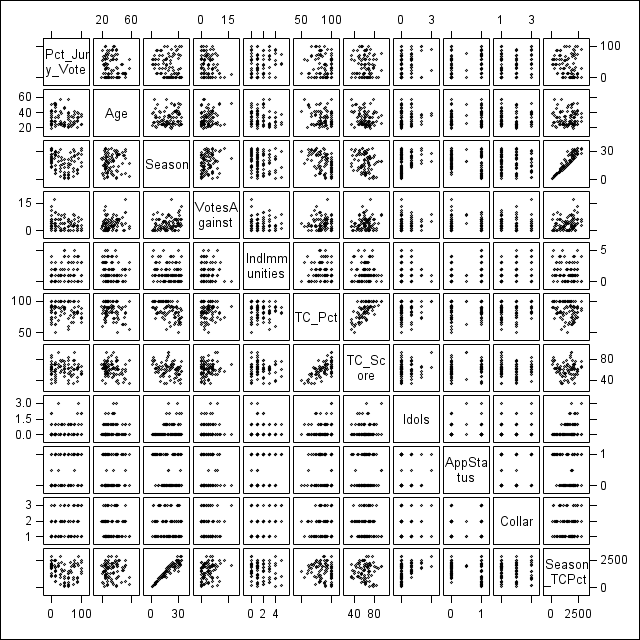

The Pearson correlation coeffecients for all pairwise associations are shown below. Most of the variables have a weak to moderate correlation with percent of jury vote received. It is evident already that some variables will likely not be utilized in the final model, but they will be used in variable selection regardless.

```sas
proc corr data = finaltribal;
    var Pct_Jury_Vote Age Season VotesAgainst IndImmunities TC_Pct TC_Score Idols AppStatus Collar season_TCPct;
run;
```

```
                            The CORR Procedure

  11  Variables:    Pct_Jury_Vote Age           Season        VotesAgainst
                    IndImmunities TC_Pct        TC_Score      Idols
                    AppStatus     Collar        Season_TCPct

                             Simple Statistics

    Variable                N          Mean       Std Dev           Sum

    Pct_Jury_Vote          84      39.28571      32.78086          3300
    Age                    84      32.96429       9.40577          2769
    Season                 84      18.36905       9.33291          1543
    VotesAgainst           84       3.83333       3.36113     322.00000
    IndImmunities          84       1.54762       1.39193     130.00000
    TC_Pct                 84      85.51275      12.56329          7183
    TC_Score               84      60.97707      13.01249          5122
    Idols                  84       0.42857       0.71618      36.00000
    AppStatus              83       0.45181       0.49148      37.50000
    Collar                 84       1.69048       0.76009     142.00000
    Season_TCPct           84          1519     731.47431        127633

                             Simple Statistics

                 Variable            Minimum       Maximum

                 Pct_Jury_Vote             0     100.00000
                 Age                19.00000      57.00000
                 Season              1.00000      33.00000
                 VotesAgainst              0      17.00000
                 IndImmunities             0       5.00000
                 TC_Pct             50.00000     100.00000
                 TC_Score           33.33333      93.33333
                 Idols                     0       3.00000
                 AppStatus                 0       1.00000
                 Collar              1.00000       3.00000
                 Season_TCPct       90.00000          2844

                     Pearson Correlation Coefficients
                        Prob > |r| under H0: Rho=0
```

[output cut: 85 more lines]

```
  Idols           0.10561     1.00000    -0.07817     0.00316     0.36819
                   0.3390                  0.4824      0.9772      0.0006
                       84          84          83          84          84

  AppStatus       0.14423    -0.07817     1.00000     0.07485    -0.30570
                   0.1933      0.4824                  0.5012      0.0049
                       83          83          83          83          83

  Collar         -0.04321     0.00316     0.07485     1.00000    -0.05760
                   0.6963      0.9772      0.5012                  0.6028
                       84          84          83          84          84

  Season_TCPct   -0.02152     0.36819    -0.30570    -0.05760     1.00000
                   0.8459      0.0006      0.0049      0.6028
                       84          84          83          84          84
```

### B. Screening of Covariates and Verification of Assumptions

Based on automatic variable selection methods in combination with criterion-based statistics, the following variables were removed from the model: season, votesagainst, indimmunities, and tc_score. Residual plots, statistics such as Cook’s D, and values of the residuals themselves confirmed no cause for concern with regard to outliers and points of high influence. Additionally, the remainder of the assumptions of the linear model (normality of resdiuals, homoscedasticity, linearity, and independence) were confirmed to apparently hold. Multicollinearity might otherwise pose minor issues in this model, but variables amongst variables most highly collinear with one another (such as tc_pct and tc_score), at least one was removed. The remaining variables only appear to have weak relationships at best.

### C. Final Model

The **final model** is given by
$$Y_i = \beta_0 + \beta_1X_{i1} + \beta_2X_{i2} + \beta_3X_{i3} + \beta_4X_{i4} + \beta_5X_{i5} + \beta_6X_{i6} + \beta_7X_{i7} + \beta_8X_{i8} + \varepsilon_i$$

where $\varepsilon_i \sim iidN(0,\sigma^2)$, $i = 1, 2, . . . , 83$, and $\beta_0, \beta_1, . . . , \beta_8,$ and $\sigma^2$ are the unknown model parameters.

## III. Statistical Analysis.

Relevant output for the fitted model, including ANOVA table, parameter estimates, and 95% confidence intervals for the parameters, is displayed below. The F value and associate p-value (4.77 and <.0001 respectively) confirm that at least one of the predictors is significantly related to percent of jury vote received. The $R^2 = .340304$, meaning that approximately 34% of the variation in percent of jury vote received by finalists can be explained by the collective effect of the predictors in the model. While this is not a relatively high $R^2$, when taking the amount of luck and variety associated with “Survivor” into account (including the fact that a person can win one season and do very poorly in another), it is easy to see that it would be impossible to account for all, or even a majority, of variation when creating a model for a reality show based upon people, relationship, and psychology.

```sas
proc glm data = finaltribal;
    class Appstatus Collar;
    model Pct_Jury_Vote = Age TC_Pct Idols AppStatus Collar season*TC_Pct /solution clparm alpha = .05;
run;
quit;
```

```
                             The GLM Procedure

                          Class Level Information

                     Class          Levels    Values

                     AppStatus           3    0 1 0.5

                     Collar              3    1 2 3

                  Number of Observations Read          84
                  Number of Observations Used          83



                             The GLM Procedure

                   Dependent Variable: Pct_Jury_Vote

                                     Sum of
 Source                    DF       Squares   Mean Square  F Value  Pr > F

 Model                      8   30104.76747    3763.09593     4.77  <.0001

 Error                     74   58359.63719     788.64375

 Corrected Total           82   88464.40466

        R-Square     Coeff Var      Root MSE    Pct_Jury_Vote Mean

        0.340304      70.90107      28.08280              39.60843


 Source                    DF     Type I SS   Mean Square  F Value  Pr > F

 Age                        1    2726.14558    2726.14558     3.46  0.0670
 TC_Pct                     1     777.97861     777.97861     0.99  0.3238
 Idols                      1    6631.89645    6631.89645     8.41  0.0049
 AppStatus                  2   11022.66238    5511.33119     6.99  0.0017
 Collar                     2    3052.33292    1526.16646     1.94  0.1516
```

[output cut: 29 more lines]

```
              Intercept               70.7413935  218.7539747
              Age                     -1.7019363   -0.3191266
              TC_Pct                  -1.1913312   -0.1210689
              Idols                   10.2539954   29.7343552
              AppStatus     0        -31.7291257   37.4211990
              AppStatus     1        -16.4361485   54.1854691
              AppStatus     0.5         .            .
              Collar        1        -33.6516024    0.9123815
              Collar        2        -36.5099101    0.8035140
              Collar        3           .            .
              TC_Pct*Season           -0.0230074   -0.0036081

NOTE: The X'X matrix has been found to be singular, and a generalized
      inverse was used to solve the normal equations.  Terms whose
      estimates are followed by the letter 'B' are not uniquely estimable.
```

### A. Utilizing the Model for Prediction

To test the utility of the model in predicting voting outcomes for “Survivor” finalists, the three finalists from the previous season (not included in the full dataset) were tested. Outcomes were compared to actual values. As evidenced, below, the model for this season underestimated the percent of jury vote received for each of the three data points. It was predicted that Troyzan would receive -5.46% of the vote (technically impossible); he actually received 0%. Brad was predicted to receive 3.10% of the jury vote; he actually received 30%. Last, Sarah was predicted to receive 14.47% of the jury vote, but she actually received 70%. Other measures could possibly be taken in “better” fitting models to account for the fact that percentages within the same season should have summed to 100.00% and to eliminate any bias retained in the final model presented. However, while the values predicted were less than the actual values, the predicted values would have correctly pointed to the winner, as predicted values ascended accordingly with the actual values.

```sas
proc import out= survpred
            datafile= "C:\Users\Brianna\Documents\Stat 840\Prediction Dataset.csv"
            dbms=CSV REPLACE;
     getnames=yes;
     datarow=2;
run;

data survpredvals;
    set survpred;
    predictval = 144.7476841 - 1.0105315*Age -0.6562001*TC_Pct + 19.9941753*Idols + 2.8460366*Recruit + 18.8746603*Applicant -16.3696105*WhiteCollar -17.8531981*NoCollar-0.0133077*(TC_Pct*Season);
    predvsactual = predictval - Pct_Jury_Vote;
run;

proc print data = survpredvals;
    var Name Age Season TC_Pct Idols Pct_Jury_Vote AppStatus Collar predictval predvsactual;
run;
```

```
 Obs Name                       Age       Season       TC_Pct        Idols

  1  Troyzan Roberston           54           34  72.72727273            0
  2  Brad Culpepper              47           34  72.72727273            0
  3  Sarah Lacina                32           34  90.90909091            0

        Pct_Jury_
 Obs         Vote     AppStatus        Collar  predictval  predvsactual

  1             0             0             2    -5.4581      -5.4581
  2            30             0             1     3.0992     -26.9008
  3            70             0             3    14.4693     -55.5307
```

## IV. Summary of Findings.

Clearly, a lot of variation still exists in this model. It is difficult to account for every variable that is responsible for the percentage of the jury vote received by jury members, especially since jury members themselves have a large degree of variation, and frequently reward players for different reasons in different seasons. Seasons 19 and 20 saw juries so bitter at their treatment in the game by Russell Hantz that he received very few votes despite dominating strategically and finding many hidden immunity idols. On the other hand, Kim Spradlin dominated season 24 and was responsible for most of the jury members’ oustings, but still easily won in the final tribal council 7-2. In season 15, Amanda Kimmel played a game easily on par with winner, Todd Herzog, but her botched arguments and inability to take responsibility for her actions at the final tribal annoyed jury members and potentially cost her the game. And finally, there are seasons like season 33 where revelations at the final tribal council reward sympathy points to the ultimate winner (Adam Klein revealed that his mother was dying) resulting in a 10-0-0 vote which would likely not have been quite so unanimous otherwise (runner-up Ken McNickle played a game which in any other season likely would have rewarded him with at least a portion of the jury vote).

Overall, it is difficult to predict something as fickle as a “Survivor” jury’s whims. However, this model does explain approximately 34% of the variation in jury vote, and given the nature of the game, that does offer some degree of value (such as the ability of the model to correctly predict the order of placement via predicted percentages received of the finalists in season 34).

## V. Appendix

### A. Diagnostics for Predictors

The purpose of this section is to check predictors for outlier values. Boxplots created show some skewness, but overall no major problems with outliers.

```
data finaltribal;
set finaltribal;
group = 1;
run;

proc boxplot data = finaltribal;
plot Pct_Jury_Vote*group;
plot Age*group;
plot TC_Pct*group;
plot Idols*group;
plot AppStatus*group;
plot Collar*group;
plot season_TCPct*group;
run;
```

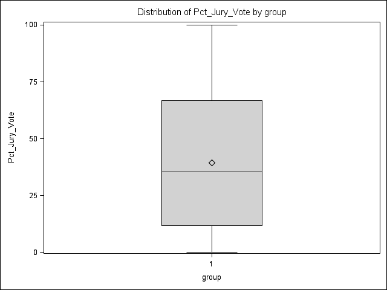

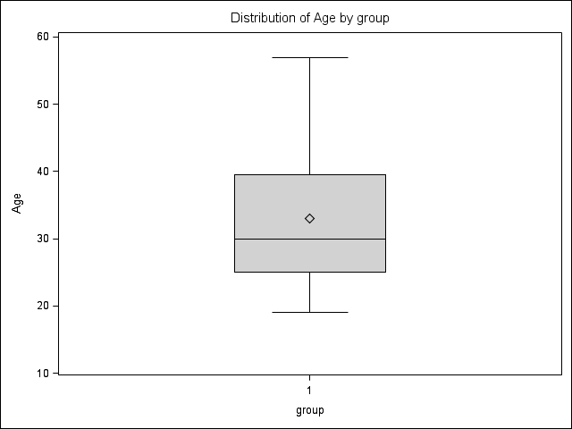

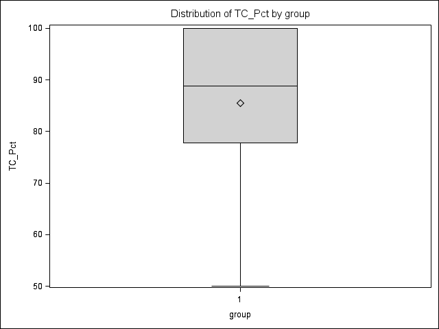

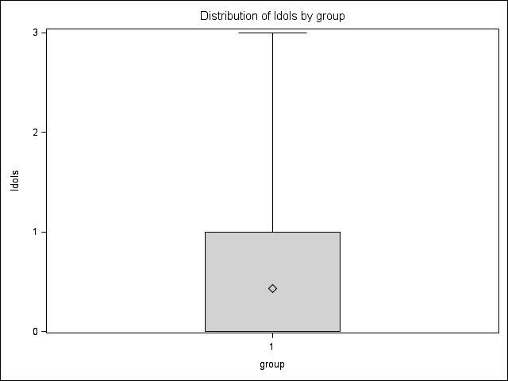

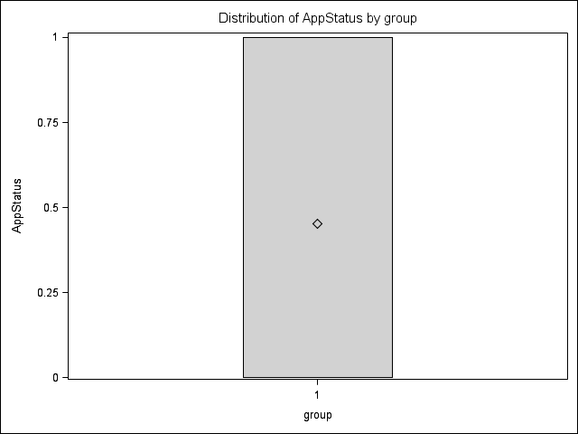

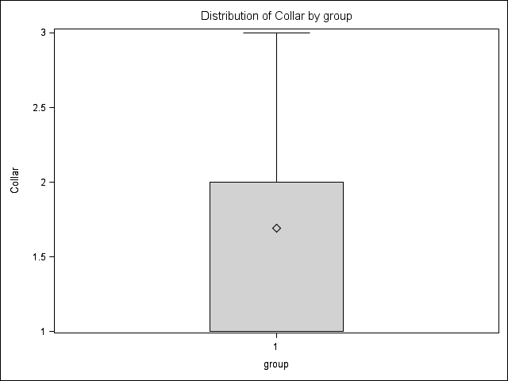

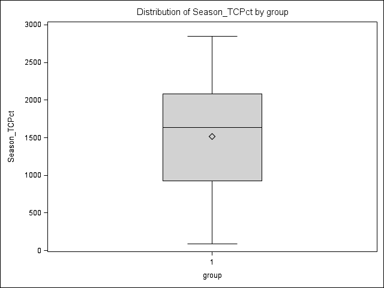

### B. Screening of Predictors

1. **Added variable plots** for each predictor are included below. The categorical variables (applicant and collar) do not look impressively linear, but that is unsurprising. The others, while not strongly linear, do show weak to moderate linearity. Overall, the plots indicate no need for transformations, and that the predictors do have value in the final model.

```
proc reg data = finaltribal;
model Pct_Jury_Vote = Age TC_Pct Idols Applicant Recruit BlueCollar WhiteCollar season_TCPct /partial;
run;
quit;
```

Model: MODEL1

Dependent Variable: Pct_Jury_Vote

| Number of Observations Read | 84 |
| --- | --- |
| Number of Observations Used | 84 |

| Analysis of Variance Source | Analysis of Variance DF | Analysis of Variance Sum of Squares | Analysis of Variance Mean Square | Analysis of Variance F Value | Analysis of Variance Pr > F |
| --- | --- | --- | --- | --- | --- |
| Model | 8 | 30828 | 3853.48909 | 4.95 | <.0001 |
| Error | 75 | 58363 | 778.16814 |  |  |
| Corrected Total | 83 | 89191 |  |  |  |

| Root MSE | 27.89567 | R-Square | 0.3456 |
| --- | --- | --- | --- |
| Dependent Mean | 39.28571 | Adj R-Sq | 0.2758 |
| Coeff Var | 71.00715 |  |  |

| Parameter Estimates Variable | Parameter Estimates DF | Parameter Estimates Parameter Estimate | Parameter Estimates Standard Error | Parameter Estimates t Value | Parameter Estimates Pr > \|t\| |
| --- | --- | --- | --- | --- | --- |
| Intercept | 1 | 126.23709 | 32.82112 | 3.85 | 0.0002 |
| Age | 1 | -1.01205 | 0.34381 | -2.94 | 0.0043 |
| TC_Pct | 1 | -0.65385 | 0.26405 | -2.48 | 0.0155 |
| Idols | 1 | 20.04346 | 4.78983 | 4.18 | <.0001 |
| Applicant | 1 | 19.39790 | 15.43470 | 1.26 | 0.2127 |
| Recruit | 1 | 3.36282 | 15.07355 | 0.22 | 0.8241 |
| BlueCollar | 1 | 17.81499 | 9.28031 | 1.92 | 0.0587 |
| WhiteCollar | 1 | 1.44806 | 6.96140 | 0.21 | 0.8358 |
| Season_TCPct | 1 | -0.01331 | 0.00483 | -2.75 | 0.0074 |

Model: MODEL1

Dependent Variable: Pct_Jury_Vote

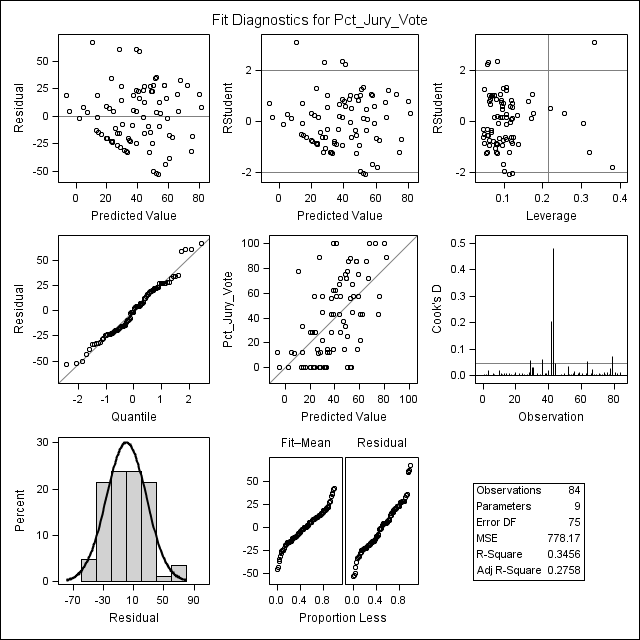

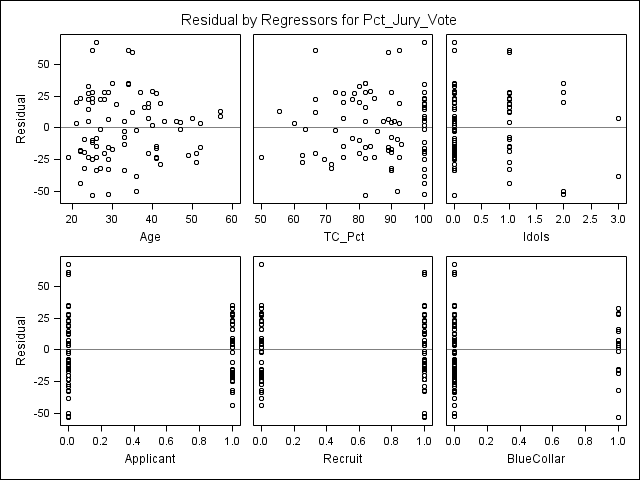

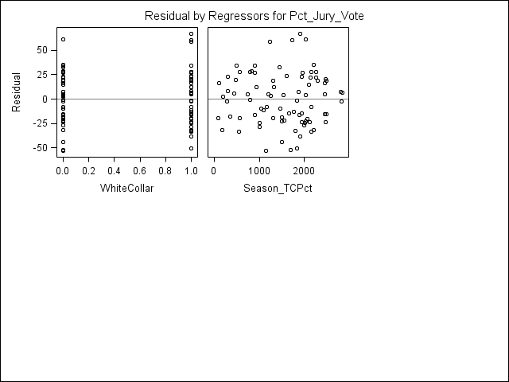

Model: MODEL1

Partial Regression Residual Plot

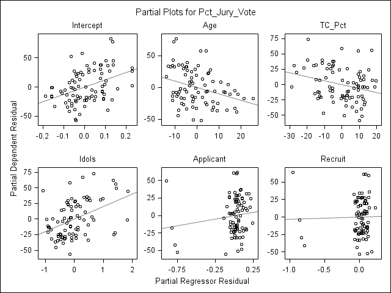

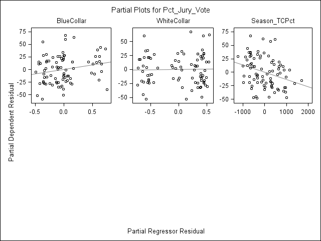

2. A scatterplot matrix and correlation matrix were created for the final predictors to assess for multicollinearity. Multicollinearity, or a high degree of association amongst predictor variables, can create a model that is not stable. These matrices, displayed below, show a moderate degree of association between the tribal council percent x season interaction term, and both idols and applicant status. All other variables have weak associations at most. The degree of potentiall muticollinearity presented by these findings does not pose great cause for concern.

```
proc sgscatter data = finaltribal;
    matrix Pct_Jury_Vote Age TC_Pct Idols AppStatus Collar season_TCPct;
run;
```

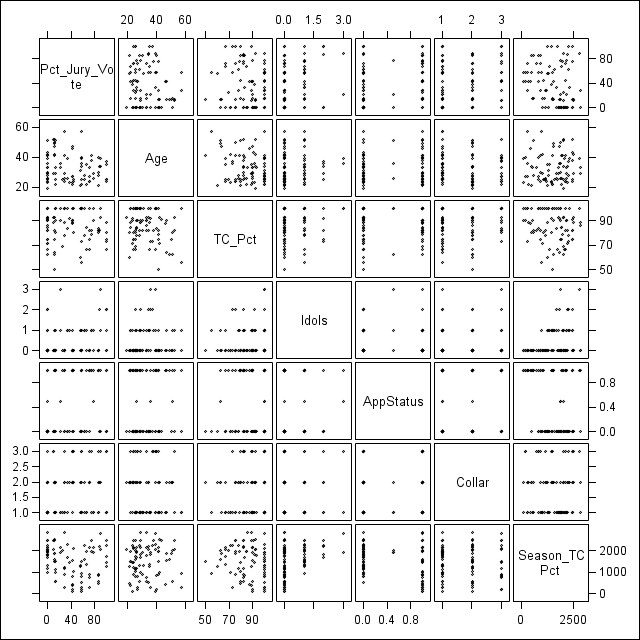

```sas
proc corr data = finaltribal;
    var Pct_Jury_Vote Age TC_Pct Idols AppStatus Collar season_TCPct;
run;
```

```
                            The CORR Procedure

   7  Variables:    Pct_Jury_Vote Age           TC_Pct        Idols
                    AppStatus     Collar        Season_TCPct

                             Simple Statistics

    Variable                N          Mean       Std Dev           Sum

    Pct_Jury_Vote          84      39.28571      32.78086          3300
    Age                    84      32.96429       9.40577          2769
    TC_Pct                 84      85.51275      12.56329          7183
    Idols                  84       0.42857       0.71618      36.00000
    AppStatus              83       0.45181       0.49148      37.50000
    Collar                 84       1.69048       0.76009     142.00000
    Season_TCPct           84          1519     731.47431        127633

                             Simple Statistics

                 Variable            Minimum       Maximum

                 Pct_Jury_Vote             0     100.00000
                 Age                19.00000      57.00000
                 TC_Pct             50.00000     100.00000
                 Idols                     0       3.00000
                 AppStatus                 0       1.00000
                 Collar              1.00000       3.00000
                 Season_TCPct       90.00000          2844

                     Pearson Correlation Coefficients
                        Prob > |r| under H0: Rho=0
                          Number of Observations

                          Pct_
                         Jury_
                          Vote           Age        TC_Pct         Idols

   Pct_Jury_Vote       1.00000      -0.18731      -0.04065       0.24031
                                      0.0880        0.7136        0.0277
                            84            84            84            84
```

[output cut: 44 more lines]

```
          Idols              -0.07817       0.00316       0.36819
                               0.4824        0.9772        0.0006
                                   83            84            84

          AppStatus           1.00000       0.07485      -0.30570
                                             0.5012        0.0049
                                   83            83            83

          Collar              0.07485       1.00000      -0.05760
                               0.5012                      0.6028
                                   83            84            84

          Season_TCPct       -0.30570      -0.05760       1.00000
                               0.0049        0.6028
                                   83            84            84
```

3. Automatic variable selection was used to determine which model was best utilized as the final model. Many criteria were examined, and the model which seemed best according to the most criteria was used. The model which minimized AIC, minimized Mallow’s $C{p}$, and maximized $R^2{adj}$ corresponds to the final model which was selected.

```
ods graphics on;
proc glmselect data = finaltribal plot = CriterionPanel;
    class AppStatus Collar;
    model Pct_Jury_Vote = Age Season VotesAgainst IndImmunities TC_Pct TC_Score Idols AppStatus Collar season*TC_Pct
    /selection = stepwise(select = cp) stats = all;
run;
quit;
ods graphics off;
```

| Data Set | WORK.FINALTRIBAL |
| --- | --- |
| Dependent Variable | Pct_Jury_Vote |
| Selection Method | Stepwise |
| Select Criterion | C(p) |
| Stop Criterion | C(p) |
| Effect Hierarchy Enforced | None |

| Number of Observations Read | 84 |
| --- | --- |
| Number of Observations Used | 83 |

| Class Level Information Class | Class Level Information Levels | Class Level Information Values |
| --- | --- | --- |
| AppStatus | 3 | 0 1 0.5 |
| Collar | 3 | 1 2 3 |

| Dimensions |  |
| --- | --- |
| Number of Effects | 11 |
| Number of Parameters | 15 |

Stepwise Selection Summary

Step

Effect  
Entered

Effect  
Removed

Number  
Effects In

Number  
Parms In

Model  
R-Square

Adjusted  
R-Square

AIC

AICC

BIC

CP

SBC

PRESS

ASE

F Value

Pr > F

0

Intercept

1

1

0.0000

0.0000

665.6357

665.7857

581.9961

30.3903

583.0546

90635.2296

1065.8362

0.00

1.0000

1

AppStatus

2

3

0.0866

0.0637

662.1208

662.6337

577.9474

24.7480

584.3774

88804.8116

973.5742

3.79

0.0267

2

Idols

3

4

0.1641

0.1324

656.7581

657.5373

572.8658

18.1109

581.4335

88682.3586

890.9302

7.33

0.0083

3

Age

4

5

0.2148

0.1745

653.5684

654.6737

570.0525

14.4673

580.6626

84063.7427

836.9296

5.03

0.0277

4

Season*TC_Pct

5

6

0.2625

0.2146

650.3673

651.8606

567.4906

11.1544

579.8803

82894.5767

786.0933

4.98

0.0286

5

TC_Pct

6

7

0.3025

0.2475

647.7323

649.6782*

565.6794*

8.6924

579.6642*

82825.1242

743.3986

4.36

0.0400

6

Collar

7

9

0.3403

0.2690*

647.1098*

650.1653

566.4072

8.4837*

583.8793

82610.2980*

703.1282

2.12

0.1274

- Optimal Value of Criterion

| Selection stopped at a local minimum of the C(p) criterion. |
| --- |

| Stop Details Candidate For | Stop Details Effect | Stop Details Candidate C(p) | Stop Details | Stop Details Compare C(p) |
| --- | --- | --- | --- | --- |
| Entry | IndImmunities | 8.8294 | > | 8.4837 |
| Removal | Collar | 8.6924 | > | 8.4837 |

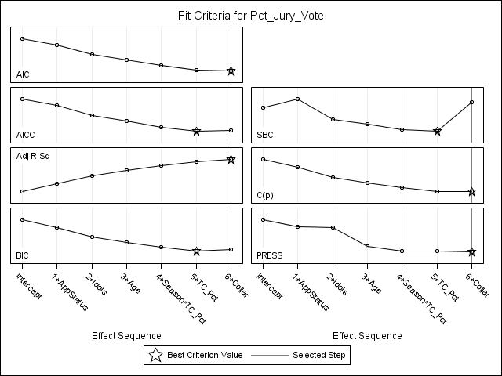

Selected Model

| The selected model is the model at the last step (Step 6). |
| --- |

| Effects: | Intercept Age TC_Pct Idols AppStatus Collar Season*TC_Pct |
| --- | --- |

| Analysis of Variance Source | Analysis of Variance DF | Analysis of Variance Sum of Squares | Analysis of Variance Mean Square | Analysis of Variance F Value |
| --- | --- | --- | --- | --- |
| Model | 8 | 30105 | 3763.09593 | 4.77 |
| Error | 74 | 58360 | 788.64375 |  |
| Corrected Total | 82 | 88464 |  |  |

| Root MSE | 28.08280 |
| --- | --- |
| Dependent Mean | 39.60843 |
| R-Square | 0.3403 |
| Adj R-Sq | 0.2690 |
| AIC | 647.10975 |
| AICC | 650.16531 |
| BIC | 566.40724 |
| C(p) | 8.48375 |
| PRESS | 82610 |
| SBC | 583.87932 |
| ASE | 703.12816 |

| Parameter Estimates Parameter | Parameter Estimates DF | Parameter Estimates Estimate | Parameter Estimates Standard Error | Parameter Estimates t Value |
| --- | --- | --- | --- | --- |
| Intercept | 1 | 144.747684 | 37.141619 | 3.90 |
| Age | 1 | -1.010531 | 0.346996 | -2.91 |
| TC_Pct | 1 | -0.656200 | 0.268567 | -2.44 |
| Idols | 1 | 19.994175 | 4.888315 | 4.09 |
| AppStatus 0 | 1 | 2.846037 | 17.352275 | 0.16 |
| AppStatus 1 | 1 | 18.874660 | 17.721475 | 1.07 |
| AppStatus 0.5 | 0 | 0 | . | . |
| Collar 1 | 1 | -16.369610 | 8.673332 | -1.89 |
| Collar 2 | 1 | -17.853198 | 9.363265 | -1.91 |
| Collar 3 | 0 | 0 | . | . |
| Season*TC_Pct | 1 | -0.013308 | 0.004868 | -2.73 |

```sas
proc glm data = finaltribal;
    class Appstatus Collar;
    model Pct_Jury_Vote = Age TC_Pct Idols AppStatus Collar season*TC_Pct /solution;
run;
quit;
```

```
                             The GLM Procedure

                          Class Level Information

                     Class          Levels    Values

                     AppStatus           3    0 1 0.5

                     Collar              3    1 2 3

                  Number of Observations Read          84
                  Number of Observations Used          83



                             The GLM Procedure

                   Dependent Variable: Pct_Jury_Vote

                                     Sum of
 Source                    DF       Squares   Mean Square  F Value  Pr > F

 Model                      8   30104.76747    3763.09593     4.77  <.0001

 Error                     74   58359.63719     788.64375

 Corrected Total           82   88464.40466

        R-Square     Coeff Var      Root MSE    Pct_Jury_Vote Mean

        0.340304      70.90107      28.08280              39.60843


 Source                    DF     Type I SS   Mean Square  F Value  Pr > F

 Age                        1    2726.14558    2726.14558     3.46  0.0670
 TC_Pct                     1     777.97861     777.97861     0.99  0.3238
 Idols                      1    6631.89645    6631.89645     8.41  0.0049
 AppStatus                  2   11022.66238    5511.33119     6.99  0.0017
 Collar                     2    3052.33292    1526.16646     1.94  0.1516
```

[output cut: 15 more lines]

```
Intercept              144.7476841 B     37.14161864       3.90      0.0002
Age                     -1.0105315        0.34699610      -2.91      0.0047
TC_Pct                  -0.6562001        0.26856686      -2.44      0.0169
Idols                   19.9941753        4.88831482       4.09      0.0001
AppStatus     0          2.8460366 B     17.35227484       0.16      0.8702
AppStatus     1         18.8746603 B     17.72147454       1.07      0.2903
AppStatus     0.5        0.0000000 B       .                .         .
Collar        1        -16.3696105 B      8.67333234      -1.89      0.0630
Collar        2        -17.8531981 B      9.36326466      -1.91      0.0604
Collar        3          0.0000000 B       .                .         .
TC_Pct*Season           -0.0133077        0.00486797      -2.73      0.0078

NOTE: The X'X matrix has been found to be singular, and a generalized
      inverse was used to solve the normal equations.  Terms whose
      estimates are followed by the letter 'B' are not uniquely estimable.
```

### C. Residual Diagnostics

Residuals were checked to ensure that no model assumptions were violated.

First, residual values were checked to ensure that no outliers were present. In the case of this model, only one outlier was found. Cook’s D statistics were calculated for each residual to check for high levels of influence. This would only be a problem for any outliers found. No Cook’s D values were concerning or merited further investigation.

```
ods graphics on;
proc glm data = finaltribal plots = (diagnostics residuals);
    class Appstatus Collar;
    model Pct_Jury_Vote = Age TC_Pct Idols AppStatus Collar season*TC_Pct;
    output out=pred r=resid cookd=cooksd rstudent = rstud;
run;
quit;
ods graphics off;

proc print data = pred;
    var Name rstud;
    where abs(rstud) >= 3;
run;

proc print data = pred;
    var Name cooksd;
    where abs(cooksd) >= 1;
run;
```

| Class Level Information Class | Class Level Information Levels | Class Level Information Values |
| --- | --- | --- |
| AppStatus | 3 | 0 1 0.5 |
| Collar | 3 | 1 2 3 |

| Number of Observations Read | 84 |
| --- | --- |
| Number of Observations Used | 83 |

Dependent Variable: Pct_Jury_Vote

| Source | DF | Sum of Squares | Mean Square | F Value | Pr > F |
| --- | --- | --- | --- | --- | --- |
| Model | 8 | 30104.76747 | 3763.09593 | 4.77 | <.0001 |
| Error | 74 | 58359.63719 | 788.64375 |  |  |
| Corrected Total | 82 | 88464.40466 |  |  |  |

| R-Square | Coeff Var | Root MSE | Pct_Jury_Vote Mean |
| --- | --- | --- | --- |
| 0.340304 | 70.90107 | 28.08280 | 39.60843 |

| Source | DF | Type I SS | Mean Square | F Value | Pr > F |
| --- | --- | --- | --- | --- | --- |
| Age | 1 | 2726.14558 | 2726.14558 | 3.46 | 0.0670 |
| TC_Pct | 1 | 777.97861 | 777.97861 | 0.99 | 0.3238 |
| Idols | 1 | 6631.89645 | 6631.89645 | 8.41 | 0.0049 |
| AppStatus | 2 | 11022.66238 | 5511.33119 | 6.99 | 0.0017 |
| Collar | 2 | 3052.33292 | 1526.16646 | 1.94 | 0.1516 |
| TC_Pct*Season | 1 | 5893.75152 | 5893.75152 | 7.47 | 0.0078 |

| Source | DF | Type III SS | Mean Square | F Value | Pr > F |
| --- | --- | --- | --- | --- | --- |
| Age | 1 | 6688.54031 | 6688.54031 | 8.48 | 0.0047 |
| TC_Pct | 1 | 4708.13109 | 4708.13109 | 5.97 | 0.0169 |
| Idols | 1 | 13193.78857 | 13193.78857 | 16.73 | 0.0001 |
| AppStatus | 2 | 4644.78463 | 2322.39231 | 2.94 | 0.0588 |
| Collar | 2 | 3342.45026 | 1671.22513 | 2.12 | 0.1274 |
| TC_Pct*Season | 1 | 5893.75152 | 5893.75152 | 7.47 | 0.0078 |

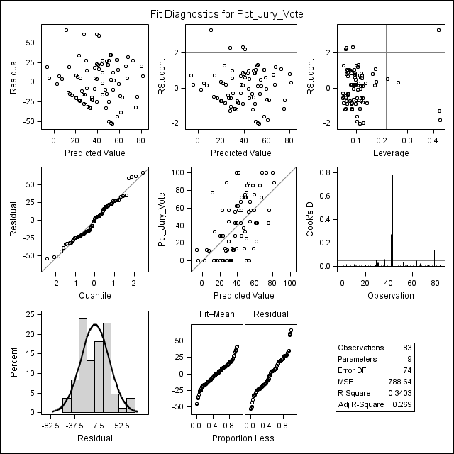

| Obs | Name | rstud |
| --- | --- | --- |
| 43 | Natalie White | 3.31973 |

In addition, the predicted versus residual plot displayed above confirms many assumptions: it looks randomly distributed, with a mean of zero, no prominent variance problems as confirmed by no clear funneling of residual values, and no apparent issues with independence of error terms.

```sas
proc glm data = finaltribal noprint;
    class Appstatus Collar;
    model Pct_Jury_Vote = Age TC_Pct Idols AppStatus Collar season*TC_Pct /solution;
    output out=pred r=resid cookd=cooksd rstudent = rstud;
run;
quit;

proc univariate data = pred normal;
    var resid;
run;
```

```
                         The UNIVARIATE Procedure
                             Variable:  resid

                                  Moments

      N                          83    Sum Weights                 83
      Mean                        0    Sum Observations             0
      Std Deviation      26.6777603    Variance            711.702893
      Skewness           0.27190809    Kurtosis            -0.2728154
      Uncorrected SS     58359.6372    Corrected SS        58359.6372
      Coeff Variation             .    Std Error Mean      2.92826461

                        Basic Statistical Measures

              Location                    Variability

          Mean     0.000000     Std Deviation           26.67776
          Median   2.223321     Variance               711.70289
          Mode      .           Range                  119.97614
                                Interquartile Range     40.73790

                        Tests for Location: Mu0=0

             Test           -Statistic-    -----p Value------

             Student's t    t         0    Pr > |t|    1.0000
             Sign           M       0.5    Pr >= |M|   1.0000
             Signed Rank    S       -34    Pr >= |S|   0.8784

                           Tests for Normality

        Test                  --Statistic---    -----p Value------

        Shapiro-Wilk          W     0.974926    Pr < W      0.1041
        Kolmogorov-Smirnov    D     0.093797    Pr > D      0.0715
        Cramer-von Mises      W-Sq  0.107245    Pr > W-Sq   0.0912
        Anderson-Darling      A-Sq  0.667333    Pr > A-Sq   0.0824

                          Quantiles (Definition 5)

```

[output cut: 18 more lines]

```
                   Value      Obs           Value      Obs

                -53.3980       29         35.2163       67
                -52.1803       36         59.0399       30
                -50.2842       44         60.8526       64
                -43.6643       31         61.1095       52
                -38.8546       42         66.5782       43

                               Missing Values

                                       -----Percent Of-----
                Missing                             Missing
                  Value       Count     All Obs         Obs

                      .           1        1.19      100.00
```